# SoK: State of the Krawlers– Evaluating the Effectiveness of Crawling Algorithms for Web Security Measurements

# Similarity

- Algorithms designed to test the similarity of pages
  - URL Equality
  - RTED
  - SimHash
  - URL Path Equality
  - RTED-1, RTED-2, and RTED-3

# Results

# Best Performance: Navigation

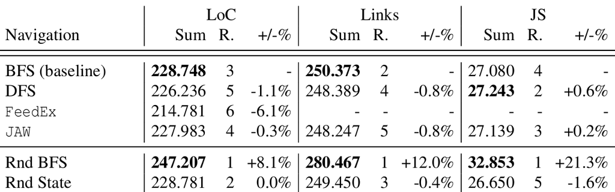

# Best Performance: Similarity

- RTED-2 performed best for the LoC metric
- Url Path Eq & QS performed best for link discovery
- RTED-3 performed best for javascript source coverage

# Best Performance: Configurations

- Configurations are a combination of algorithms suited for different tasks
- Random BFS + RTED-3 performed the best out of the chosen configurations for code coverage
- Random BFS + Url Path Eq performed best for link discovery
- Random BFS + Url Path Eq performed best for javascript discovery

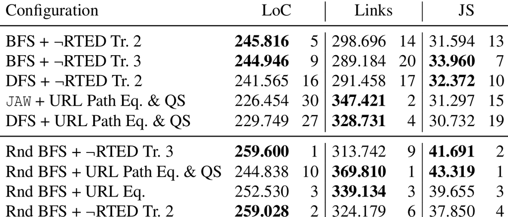

# Metrics over time

- Almost all metrics should grow at a somewhat consistent rate over time as the crawler crawls
- If there is a lack of growth, or no growth at all, it demonstrates at a crawler using sub optimal algorithms

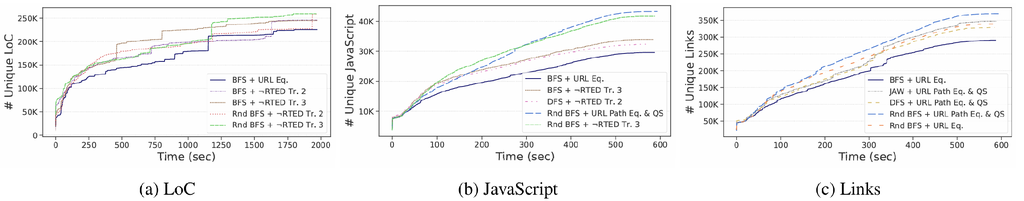

# Metrics over time cont…

- However, there is diminishing return showed by not only the previous charts bottoming out, but also the rapidly of hits rapidly declining in most cases.
- This occurs due to a lack of non-duplicate links the crawler will eventually run into given its configuration

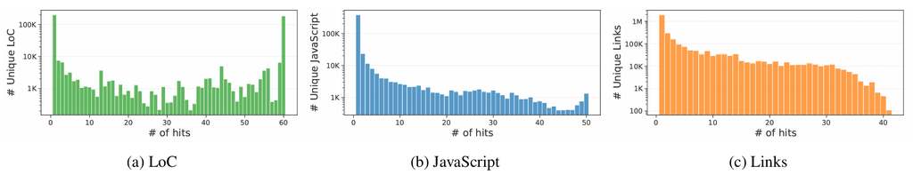

# Conclusions

# Key Findings

- Commonly used web crawling algorithms do not always perform the best
  - As we saw, randomized bfs performed better than standard bfs
- Randomized algorithms (such as randomized bfs) are really good at total coverage analysis
- Web crawling algorithms should be applied based on a target metric
- Optimized web crawling algorithms may not matter based on available system resources

# Summary

- There is no “best” crawling methods; trade-offs depend on the goal
- Reproducibility is still a major challenge

# References

Stafeev, A., & Pellegrino, G. (2024). SoK: State of the Krawlers – Evaluating the Effectiveness of Crawling Algorithms for Web Security Measurements. In Proceedings of the 33rd USENIX Security Symposium (pp. 719–737). USENIX Association.

# Questions?

# Performance differences: BFS and randomized BFS

```python
import random
import time
from collections import deque

class WebCrawler:
    def __init__(self, start_url, strategy="bfs", max_pages=1000):
        self.start_url = start_url
        self.strategy = strategy
        self.max_pages = max_pages
        self.visited = set()
        self.pages_crawled = 0

    def fetch_links(self, url):
        """Simulates fetching links from a webpage."""
        return [f"{url}/page{i}" for i in range(1, 4)]

    def crawl_bfs(self):
        queue = deque([self.start_url])
        while queue and self.pages_crawled < self.max_pages:
            url = queue.popleft()
            if url in self.visited:
                continue
            self.visited.add(url)
            self.pages_crawled += 1
            queue.extend([link for link in self.fetch_links(url) if link not in self.visited])

    def crawl_randomized_bfs(self):
        queue = [self.start_url]
        while queue and self.pages_crawled < self.max_pages:
            random.shuffle(queue)
            url = queue.pop(0)
            if url in self.visited:
                continue
            self.visited.add(url)
            self.pages_crawled += 1
            queue.extend([link for link in self.fetch_links(url) if link not in self.visited])

    def start_crawl(self):
        start_time = time.time()
        if self.strategy == "bfs":
            self.crawl_bfs()
        elif self.strategy == "random_bfs":
            self.crawl_randomized_bfs()
        else:
            raise ValueError("Unknown crawling strategy")
        end_time = time.time()
        return end_time - start_time, self.pages_crawled

# Running the experiment
start_url = "http://example.com"

bfs_crawler = WebCrawler(start_url, strategy="bfs", max_pages=100)
bfs_time, bfs_pages = bfs_crawler.start_crawl()
print(f"BFS: Time Taken = {bfs_time:.4f} sec, Pages Crawled = {bfs_pages}")

random_bfs_crawler = WebCrawler(start_url, strategy="random_bfs", max_pages=100)
random_bfs_time, random_bfs_pages = random_bfs_crawler.start_crawl()
print(f"Randomized BFS: Time Taken = {random_bfs_time:.4f} sec, Pages Crawled = {random_bfs_pages}")
```

```
BFS: Time Taken = 0.0007 sec, Pages Crawled = 100
Randomized BFS: Time Taken = 0.0081 sec, Pages Crawled = 100
```

# Webcrawler Example using beautifulsoup4

```python
# Import libraries
import re
import requests
import pandas as pd
import holoviews as hv
import networkx as nx
from holoviews import opts
from bs4 import BeautifulSoup
from urllib.parse import urljoin

# Holoviews extension for graph
hv.extension('bokeh')

def web_crawler(seed_url, max_depth=2, max_pages=2):
    visited = set()
    to_visit = [(seed_url, 0)]
    graph = nx.Graph()
    data = []

    while to_visit and len(visited) < max_pages:
        url, depth = to_visit.pop(0)
        if url in visited or depth > max_depth:
            continue
        try:
            response = requests.get(url, timeout=5)
            soup = BeautifulSoup(response.text, 'html.parser')
            # Extract links
            for link in soup.find_all('a', href=True):
                absolute_url = urljoin(url, link['href'])
                if absolute_url not in visited:
                    to_visit.append((absolute_url, depth + 1))
                graph.add_edge(url, absolute_url)
                data.append({"from": url, "to": absolute_url})
            visited.add(url)
        except Exception as e:
            print(f"Error fetching {url}: {e}")
    return pd.DataFrame(data), graph

# Run the crawler
df, G = web_crawler("https://wikipedia.com")

# Display results
print("Crawled Links:")
display(df.head())

# Visualize the network graph
nodes = hv.Dataset(pd.DataFrame(G.nodes(), columns=['URL']), 'URL')
graph = hv.Graph.from_networkx(G, nx.spring_layout).opts(
    opts.Graph(width=800, height=600, directed=False, node_size=5, edge_line_width=1))
graph
```

[output not shown]

```
%opts magic unavailable (pyparsing cannot be imported)
%compositor magic unavailable (pyparsing cannot be imported)
```

```
Crawled Links:
```

|  | from | to |
| --- | --- | --- |
| 0 | https://wikipedia.com | https://en.wikipedia.org/ |
| 1 | https://wikipedia.com | https://ja.wikipedia.org/ |
| 2 | https://wikipedia.com | https://ru.wikipedia.org/ |
| 3 | https://wikipedia.com | https://de.wikipedia.org/ |
| 4 | https://wikipedia.com | https://es.wikipedia.org/ |